# La Junta Price Estimation

Connor Krenzer

4/20/2021

# Introduction

The classification models helped us get a better sense of the cattle categories, so now the most important question should be asked: *How can we effectively predict the price?*

This document estimates the price of cattle in the La Junta sale barn.

To make this data time-series compatible, sales need to be grouped according to the date on which the sale took place. Therefore, the weekly values of the price are the median for that reproductive status (steers, heifers, etc.) at each sale. The median was chosen over the mean to reduce the chance that a few very expensive livestock can raise the average price higher than the rest of the cattle sold on the same date.

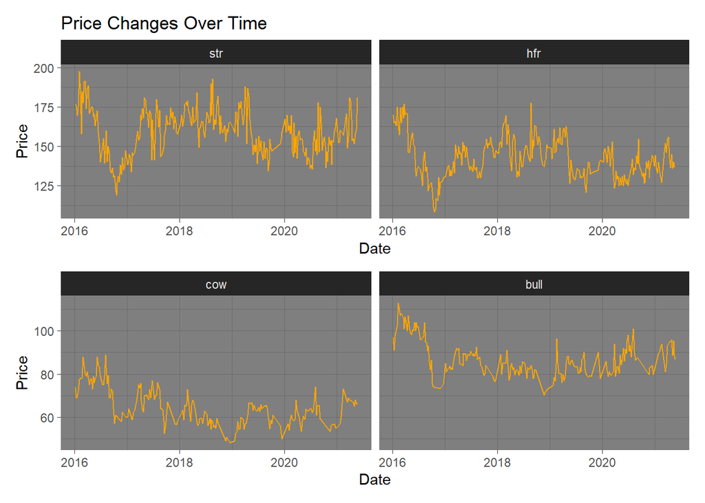

# Simple Moving Average

I am sure someone wrote a fine package with functions calculating the simple moving average, but let’s just use the one I wrote below. We can use it to get a feel for where the market is going.

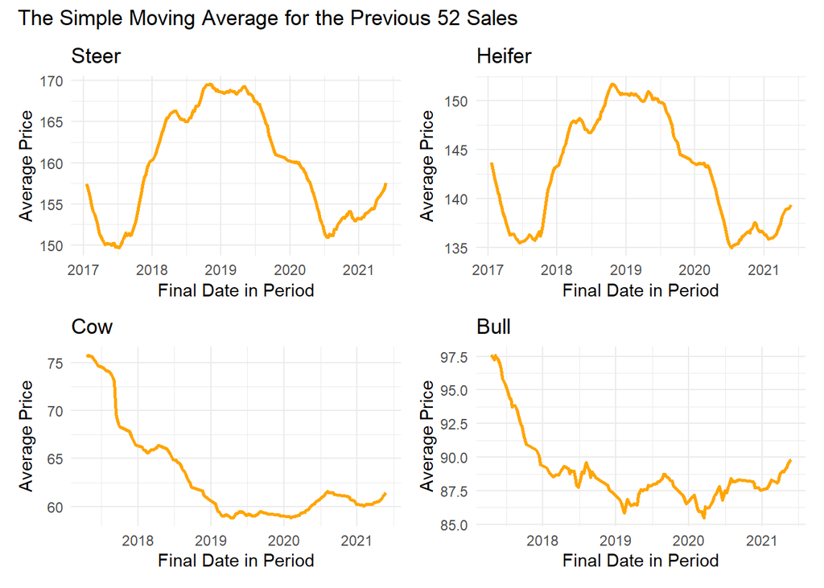

We can see the market is on an upward trajectory from lows of 2020. Whether theses gains will continue beyond the recovery point remains a question only time will tell. But, for now anyway, we see sales prices increasing.

# ARIMA

Let’s use an ARIMA model to predict the sales price of the different reproductive statuses of cattle. I’ll let someone write the functions for me this time!

### Data Prep

The data prep follows these steps:

- Store subsets of the data (steers, heifers, etc.) into their own data frames and calculate the median price at each sale. **(data prep)**
- Make the price a time series column. **(data prep)**
- Calculate moving averages for the data–eight weeks and 26 weeks (6 months) are used for this. **(data prep)**
- Calculate a new column for a seasonally adjusted variable. **(data prep)**
- Test for stationarity with the Augmented Dickey-Fuller test. **(differencing)**
- Correct for non-stationarity via differencing: Use Autocorrelation function (ACF) plots to determine the order of differencing for multiplicative models and partial autocorrelation plots (PACF) to determine the order of differencing for additive models. **(differencing)**
- Determine model parameters. **(differencing)**
- Fit and evaluate the model. **(fitting)**

### Differencing

The next steps will be completed by reproductive status, since it makes the most sense to make decisions about the model one group at a time.

If the p-value from the ADF test is not significant, the data needs to be made stationary. To do this, we must find an appropriate order of differencing, which can be found visually with the Pacf() function (or Acf() if using a multiplicative model).

```
##
##  Augmented Dickey-Fuller Test
##
## data:  ts(na.omit(avg_steer_prices$seas_adj), frequency = 8)
## Dickey-Fuller = -2.9184, Lag order = 6, p-value = 0.1895
## alternative hypothesis: stationary
```

```
## Fail to reject the null hypothesis--the data is non-stationary.
```

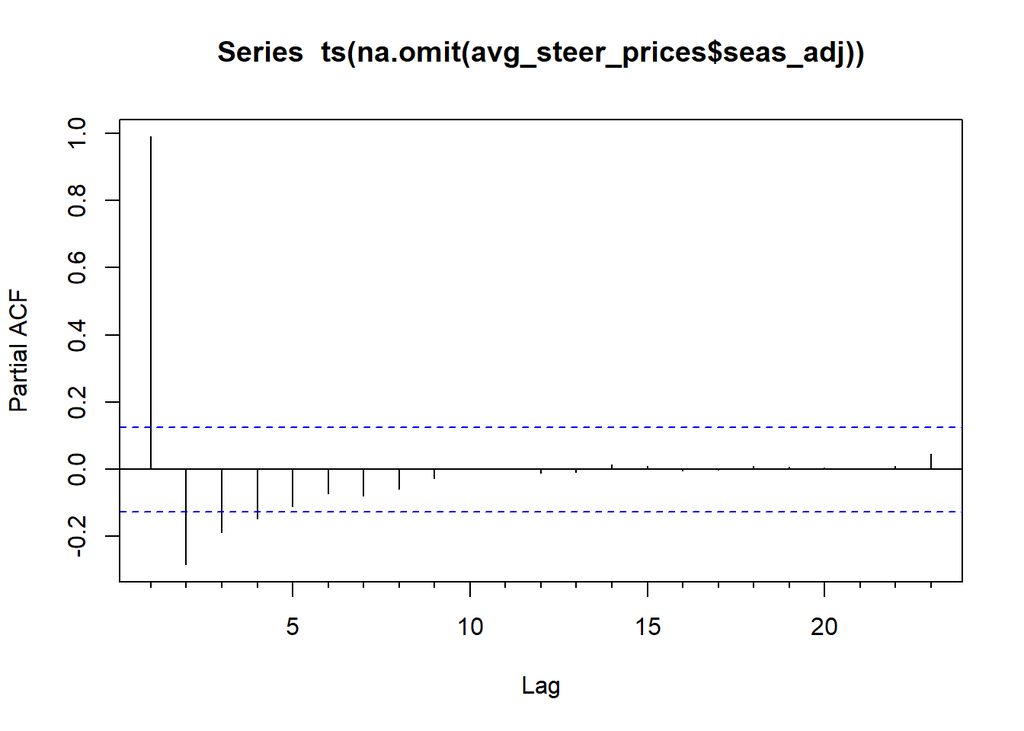

```
## The first two differences should be used.
```

```
##
##  Augmented Dickey-Fuller Test
##
## data:  na.omit(avg_steer_prices$seas_adj_diff)
## Dickey-Fuller = -6.129, Lag order = 6, p-value = 0.01
## alternative hypothesis: stationary
```

```
## The p-values on the Augmented Dickey-Fuller test are now significant. We have stationary data!
```

We now repeat the process for heifers:

```
##
##  Augmented Dickey-Fuller Test
##
## data:  ts(na.omit(avg_heifer_prices$seas_adj), frequency = 8)
## Dickey-Fuller = -3.1264, Lag order = 6, p-value = 0.102
## alternative hypothesis: stationary
```

```
## Fail to reject the null hypothesis--the data is non-stationary.
```

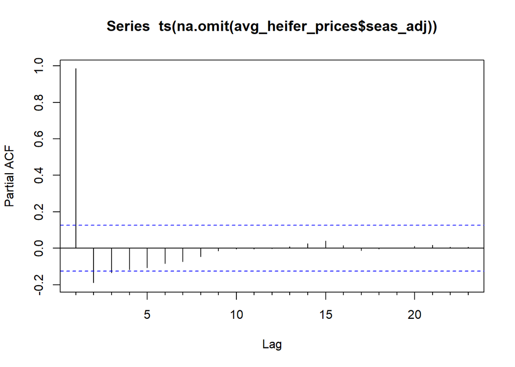

```
## The first two differences should be used.
```

```
##
##  Augmented Dickey-Fuller Test
##
## data:  na.omit(avg_heifer_prices$seas_adj_diff)
## Dickey-Fuller = -3.3384, Lag order = 6, p-value = 0.06548
## alternative hypothesis: stationary
```

[output not shown]

We repeat the process again for cows:

```
##
##  Augmented Dickey-Fuller Test
##
## data:  ts(na.omit(avg_cow_prices$seas_adj), frequency = 8)
## Dickey-Fuller = -2.7453, Lag order = 5, p-value = 0.2647
## alternative hypothesis: stationary
```

```
## Fail to reject the null hypothesis--the data is non-stationary.
```

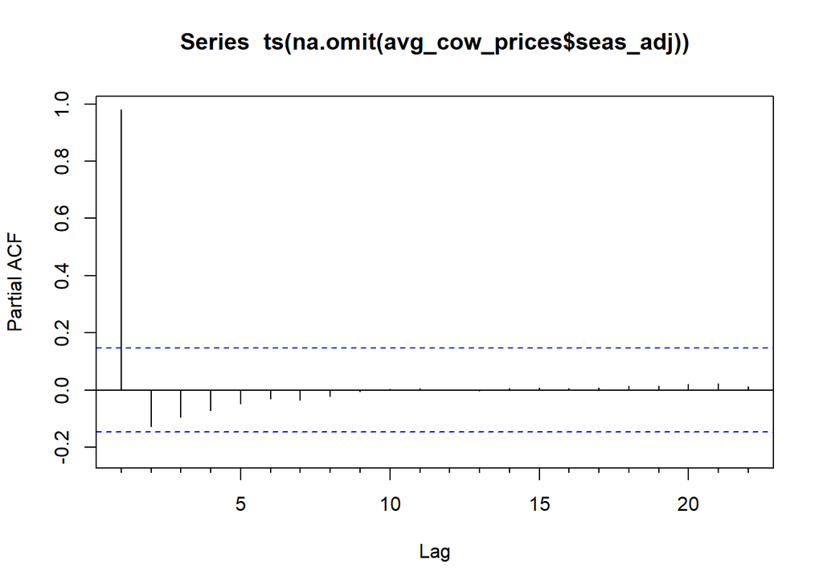

```
## The first difference should be used.
```

```
##
##  Augmented Dickey-Fuller Test
##
## data:  na.omit(avg_cow_prices$seas_adj_diff)
## Dickey-Fuller = -3.7314, Lag order = 5, p-value = 0.02391
## alternative hypothesis: stationary
```

```
## The p-values on the Augmented Dickey-Fuller test are now significant. We have stationary data!
```

We repeat the process once more for bullss:

```
##
##  Augmented Dickey-Fuller Test
##
## data:  ts(na.omit(avg_bull_prices$seas_adj), frequency = 8)
## Dickey-Fuller = -3.7096, Lag order = 5, p-value = 0.02499
## alternative hypothesis: stationary
```

[output not shown]

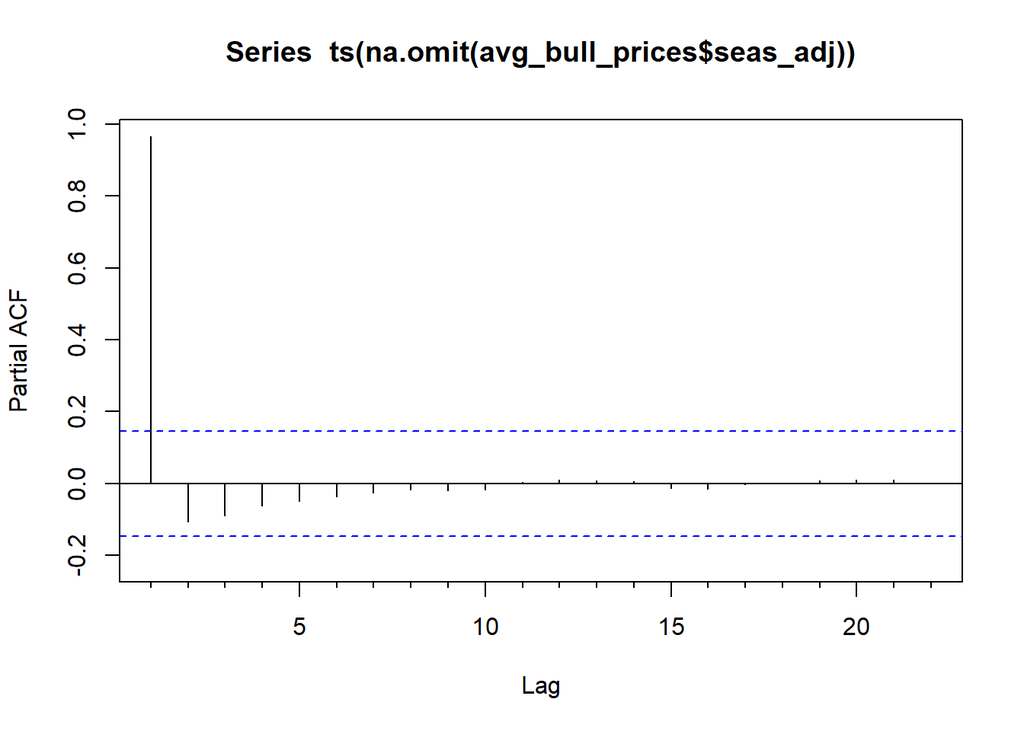

```
## The first difference should be used.
```

```
##
##  Augmented Dickey-Fuller Test
##
## data:  na.omit(avg_bull_prices$seas_adj_diff)
## Dickey-Fuller = -3.6012, Lag order = 5, p-value = 0.03505
## alternative hypothesis: stationary
```

```
## The p-values on the Augmented Dickey-Fuller test are now significant. We have stationary data!
```

### Model Fitting

- *p*: Specifies the number of **lags** (previous terms) used in the model.
- *d*: Specifies the **degree of differencing** in the integreated component. Differencing involves subtracting its current and previous values *d* times. This is used to maintain the stationarity assumption.
- *q*: Specifies the **moving average component**, or the error of the model, as a combination of previous error terms. Determines the number of terms to include in the model.

We could have just let R do all the work for us and used auto.arima() to fit the model for us, but it never hurts to build models from the ground up–a good learning exercise! Plus, doing the work manually allows us to tune the model to our liking.

### ARIMA Results

The moment we’ve all been waiting for. Where do these models say the La Junta market is going?

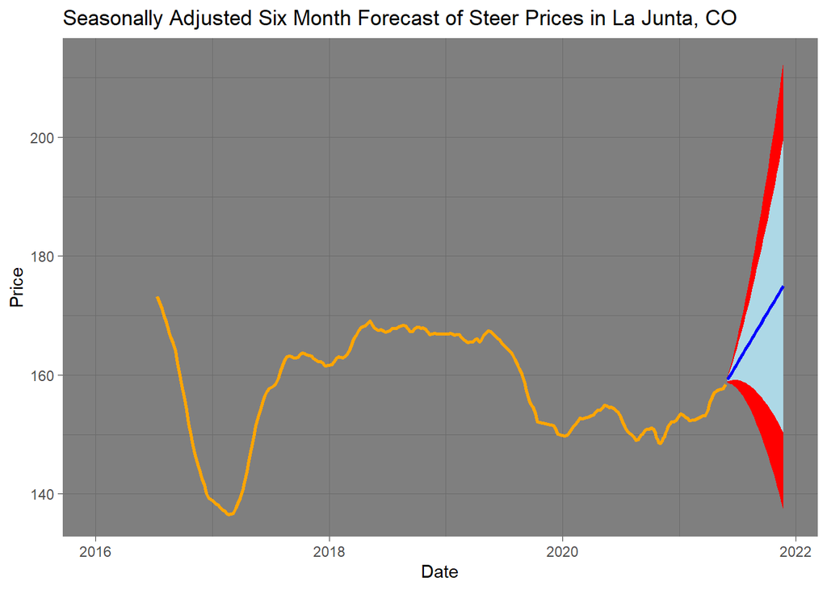

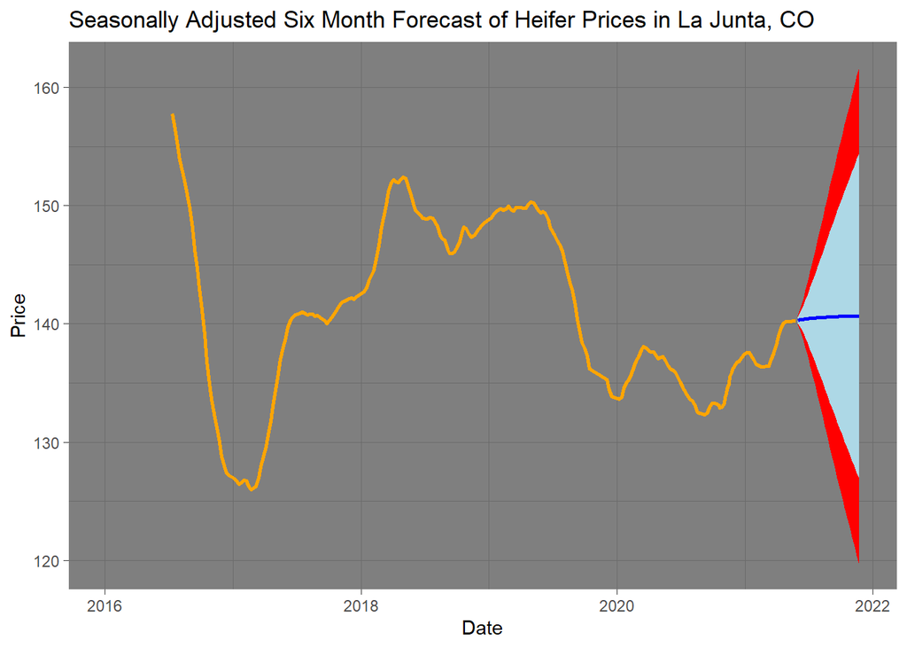

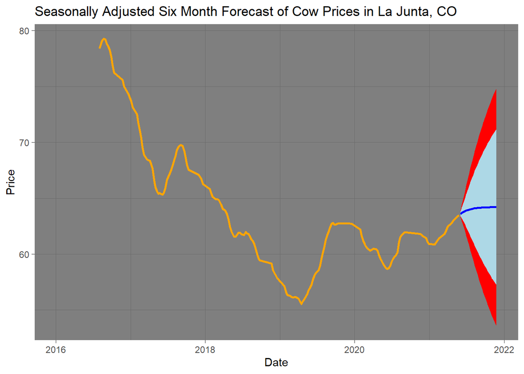

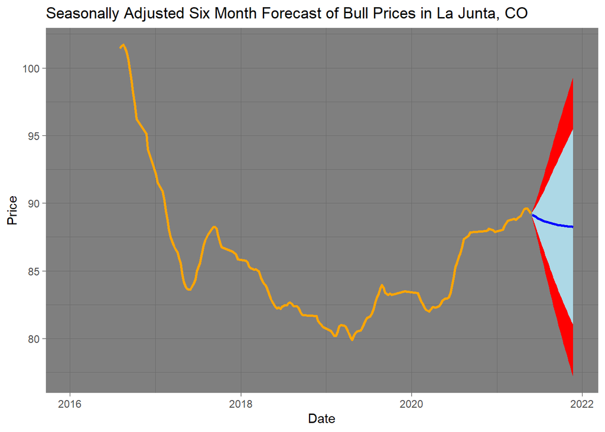

# Linear Regression

The data appears linear, so linear models seem appropriate for this dataset. There is a linear model for each reproductive status. You can see each model’s parameters below:

Now, let’s see how these models performed:

Steer Model Evaluation

| term | estimate | std.error | statistic | p.value |
| --- | --- | --- | --- | --- |
| (Intercept) | 160.5179586 | 0.2621433 | 612.329012 | 0 |
| Quantity | 0.0482382 | 0.0076533 | 6.302897 | 0 |
| poly(Weight, degree = 2)1 | -1612.2109411 | 16.6530897 | -96.811521 | 0 |
| poly(Weight, degree = 2)2 | 334.7830279 | 16.0295280 | 20.885395 | 0 |

```
## R-squared: 0.5671215
## Ajdusted R-squared: 0.5669554
## RSE: 16.00905
```

Heifer Model Evaluation

| term | estimate | std.error | statistic | p.value |
| --- | --- | --- | --- | --- |
| (Intercept) | 143.6000717 | 0.2467218 | 582.032276 | 0 |
| Quantity | 0.0754763 | 0.0078420 | 9.624661 | 0 |
| poly(Weight, degree = 2)1 | -980.6585526 | 13.9942961 | -70.075590 | 0 |
| poly(Weight, degree = 2)2 | 253.8296702 | 13.8089858 | 18.381485 | 0 |

```
## R-squared: 0.4421745
## Ajdusted R-squared: 0.4419209
## RSE: 13.76772
```

Cow Model Evaluation

| term | estimate | std.error | statistic | p.value |
| --- | --- | --- | --- | --- |
| (Intercept) | 61.3177188 | 1.4106042 | 43.469117 | 0.0000000 |
| Quantity | -0.3837557 | 0.0415418 | -9.237812 | 0.0000000 |
| Weight | 0.0037877 | 0.0010433 | 3.630441 | 0.0002885 |

```
## R-squared: 0.03975694
## Ajdusted R-squared: 0.03900499
## RSE: 8.602992
```

Bull Model Evaluation

| term | estimate | std.error | statistic | p.value |
| --- | --- | --- | --- | --- |
| (Intercept) | 78.0202627 | 1.9132647 | 40.778603 | 0.0000000 |
| Quantity | -0.3441959 | 0.1754175 | -1.962152 | 0.0499737 |
| Weight | 0.0051736 | 0.0009907 | 5.222180 | 0.0000002 |

```
## R-squared: 0.02547248
## Ajdusted R-squared: 0.02386169
## RSE: 7.947518
```

Linear regression is an art as much as it is a science. I could write [a lengthy paper](https://htmlpreview.github.io/?https://github.com/Ckrenzer/Nursing-Homes-and-COVID/blob/main/Nursing-Homes-and-COVID.html) explaining all the EDA, providing a play-by-play commentary about potential improvements to this model. But today I think I’ll leave things as they are presented here.